# ggplot2

Pierre Gestraud

4 octobre 2016

### Example data

```r
head(msleep)
```

```
##                         name      genus  vore        order conservation
## 1                    Cheetah   Acinonyx carni    Carnivora           lc
## 2                 Owl monkey      Aotus  omni     Primates         <NA>
## 3            Mountain beaver Aplodontia herbi     Rodentia           nt
## 4 Greater short-tailed shrew    Blarina  omni Soricomorpha           lc
## 5                        Cow        Bos herbi Artiodactyla domesticated
## 6           Three-toed sloth   Bradypus herbi       Pilosa         <NA>
##   sleep_total sleep_rem sleep_cycle awake brainwt  bodywt
## 1        12.1        NA          NA  11.9      NA  50.000
## 2        17.0       1.8          NA   7.0 0.01550   0.480
## 3        14.4       2.4          NA   9.6      NA   1.350
## 4        14.9       2.3   0.1333333   9.1 0.00029   0.019
## 5         4.0       0.7   0.6666667  20.0 0.42300 600.000
## 6        14.4       2.2   0.7666667   9.6      NA   3.850
```

Create additionnal variable

```r
msleep$continent <- rep(c("Europe", "Africa", "Asia"), length.out = nrow(msleep))
```

### First plot

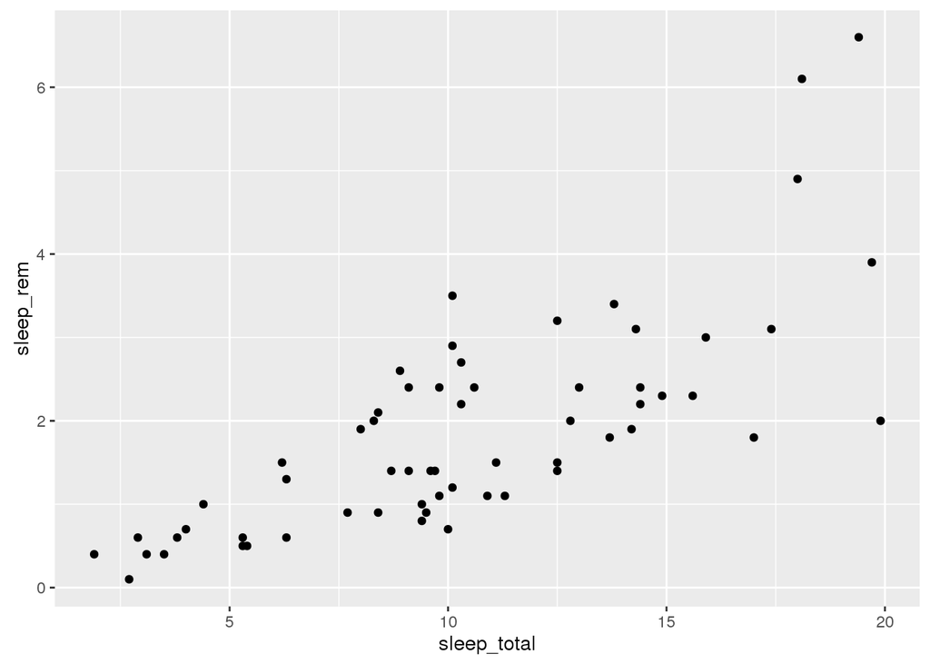

```r
qplot(sleep_total, sleep_rem, data = msleep)
```

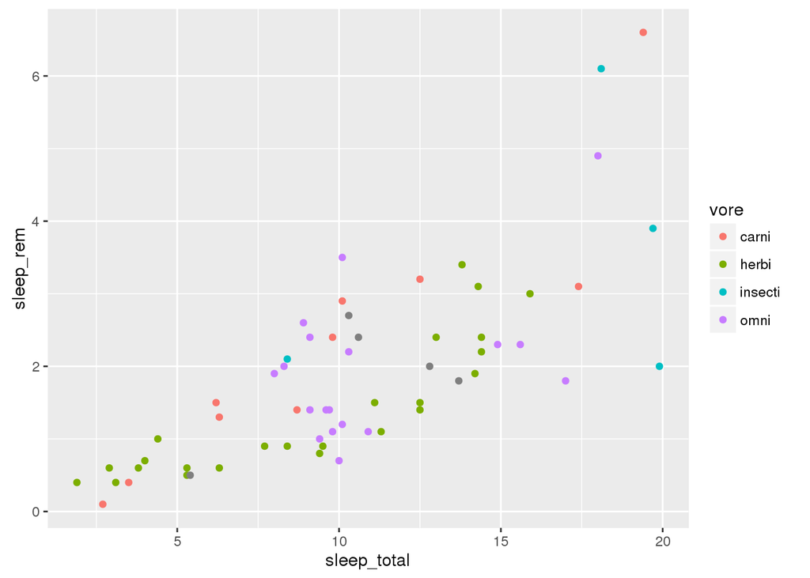

```r
qplot(sleep_total, sleep_rem, color = vore, data = msleep)
```

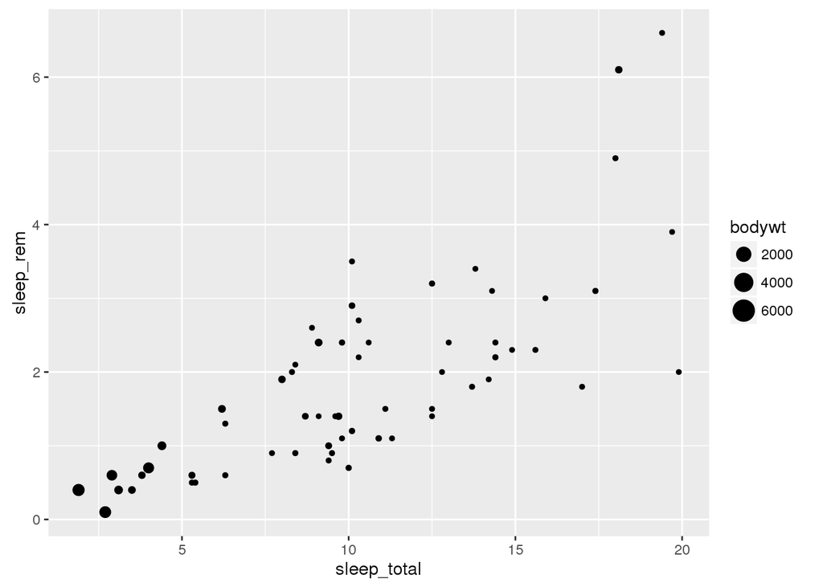

```r
qplot(sleep_total, sleep_rem, size = bodywt, data = msleep)
```

### Advanced control

main function: `ggplot`

### Grammar of graphics

plot = data + geom + coordinate system

### Layer

a layer is composed of

- data and aesthetic mapping,
- a statistical transformation,
- a geometric object
- and a position adjustement

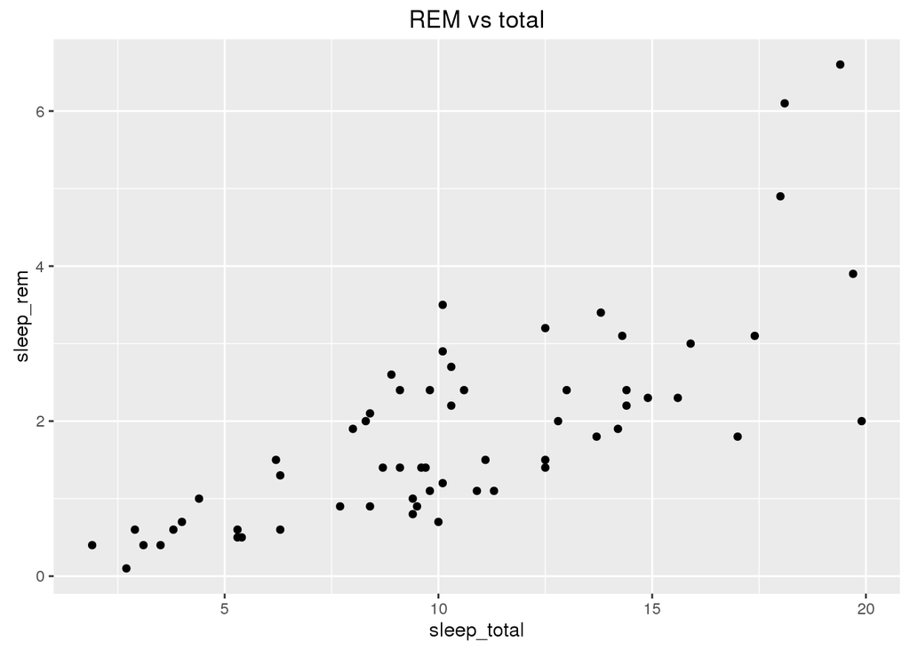

```r
ggplot(msleep,  ## data
       aes(x = sleep_total, y = sleep_rem)) + ## aesthetics
        geom_point() + ## layer
        ggtitle("REM vs total") ## additionnal elements
```

### a plot is an R object

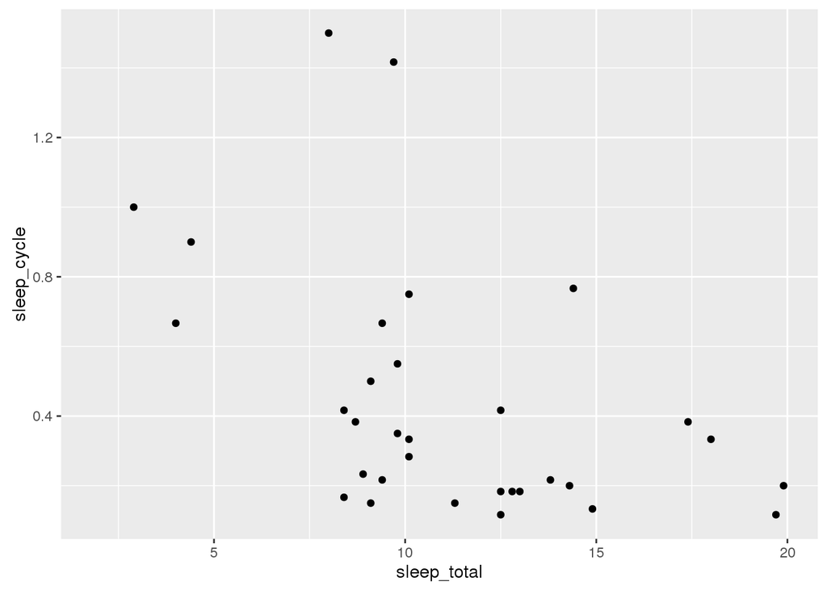

```r
g <- ggplot(msleep, aes(x = sleep_total, y = sleep_cycle)) + geom_point()
g ## or print(g)
```

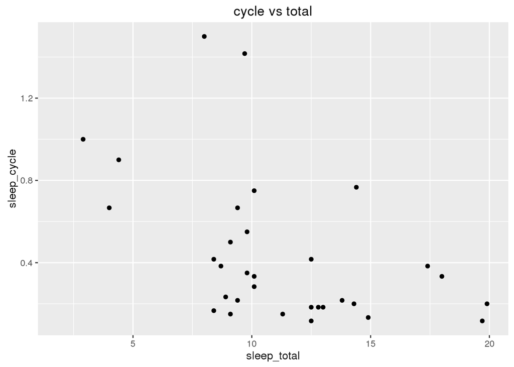

```r
g + ggtitle("cycle vs total")
```

### geom

- one variable
  - continous
    - `geom_density`
    - `geom_histogram`
    - `geom_freqpoly`
  - discrete
    - `geom_bar`
- two variables
  - continous X, continuous Y
    - `geom_point`
    - `geom_smooth`
    - `geom_text`
  - discrete X, continuous Y
    - `geom_bar`
    - `geom_boxplot`
    - `geom_violin`
  - bivariate distribution
    - `geom_density2d`
    - `geom_hex`
    - `geom_bin2d`
  - continuous function
    - `geom_line`
    - `geom_step`
- three variables
  - - `geom_contour`
    - `geom_tile`

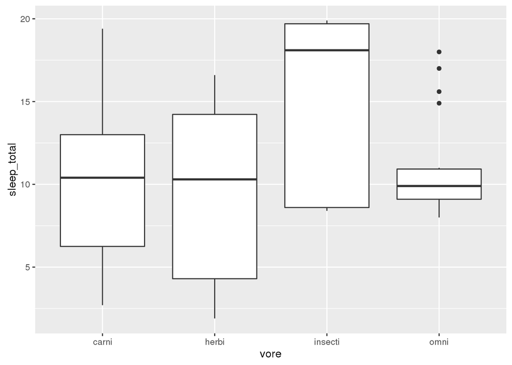

```r
ggplot(msleep, aes(x = vore, y = sleep_total)) + geom_boxplot()
```

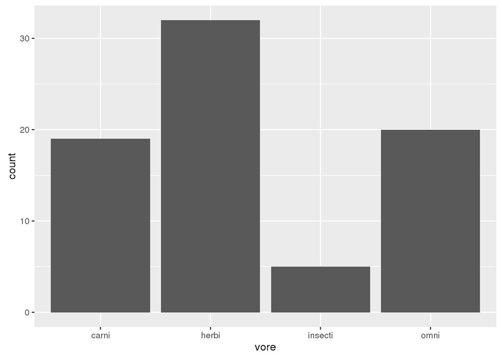

```r
ggplot(msleep, aes(x = vore)) + geom_bar()
```

### aesthetics

- `x`
- `y`
- `z`
- `color`
- `fill`
- `size`
- `text`

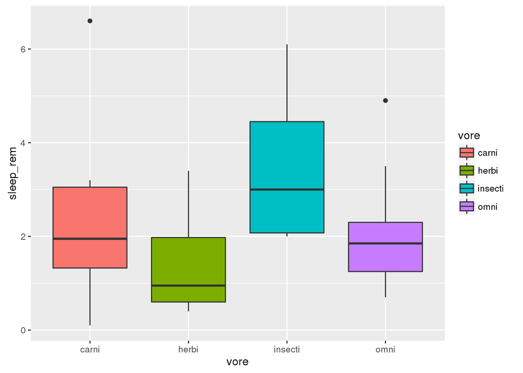

```r
ggplot(msleep, aes(x = vore, y = sleep_rem, fill = vore)) + geom_boxplot()
```

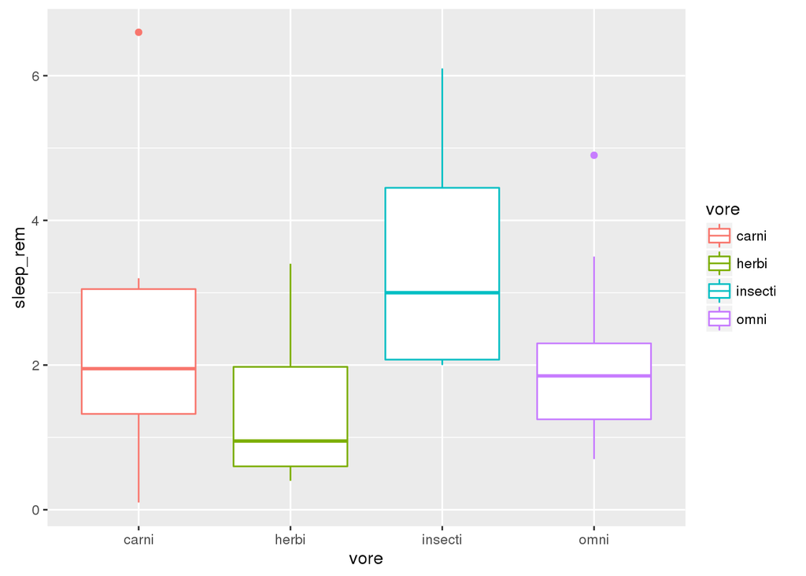

```r
ggplot(msleep, aes(x = vore, y = sleep_rem, color = vore)) + geom_boxplot()
```

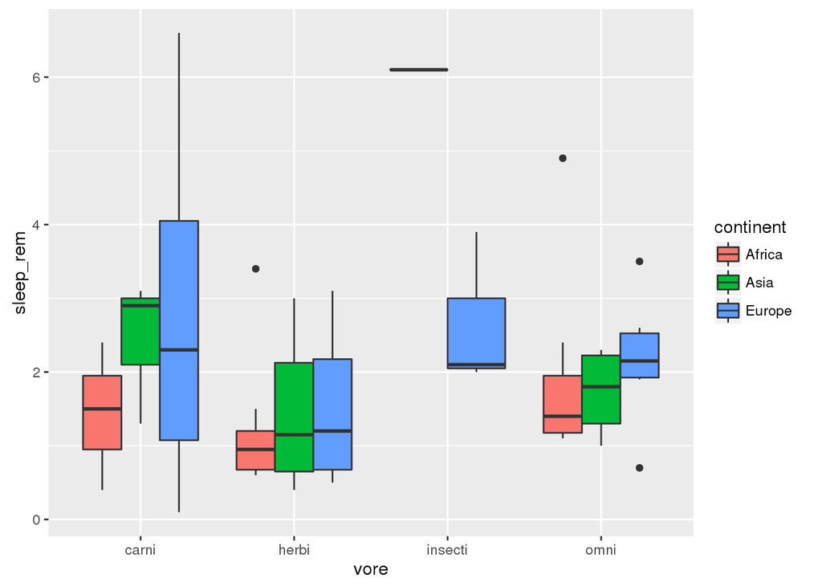

```r
ggplot(msleep, aes(x = vore, y = sleep_rem, fill = continent)) + geom_boxplot()
```

### add a smoother on the plot

Default smoother (loess if <1000 obs, gam otherwise)

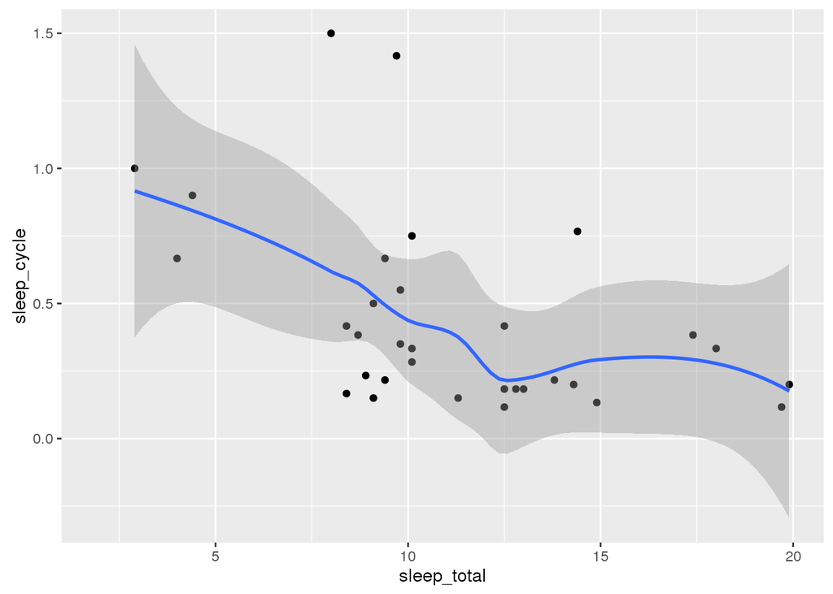

```r
ggplot(msleep, aes(x = sleep_total, y = sleep_cycle)) + geom_point() + geom_smooth()
```

Linear model

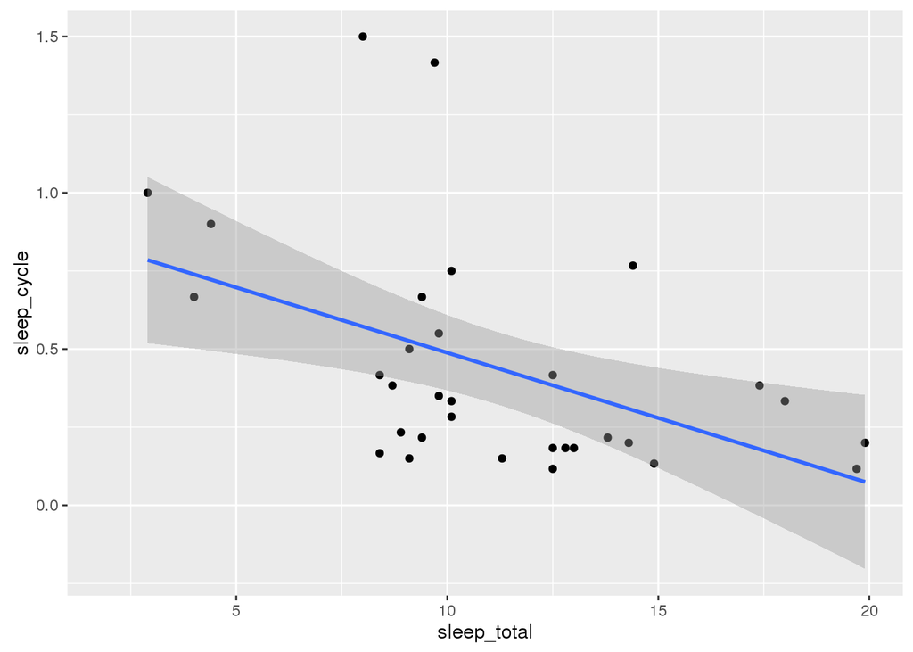

```r
ggplot(msleep, aes(x = sleep_total, y = sleep_cycle)) + geom_point() + geom_smooth(method = "lm")
```

Remove SE

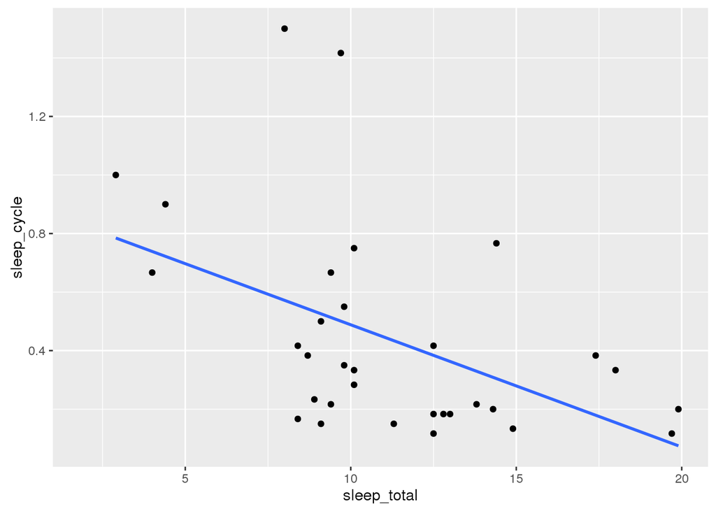

```r
ggplot(msleep, aes(x = sleep_total, y = sleep_cycle)) + geom_point() + geom_smooth(method = "lm", se = FALSE)
```

### Scales

- `xlim`/`ylim` vs `coord_cartesian`

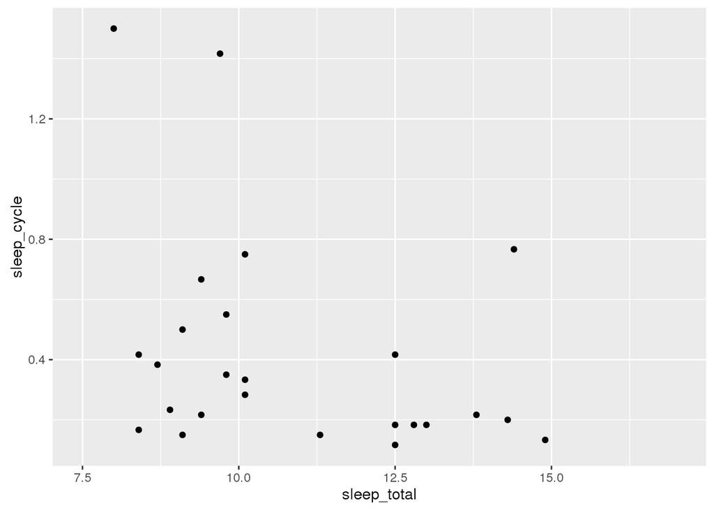

```r
ggplot(msleep, aes(x = sleep_total, y = sleep_cycle)) + geom_point() + xlim(c(7.5, 17))
```

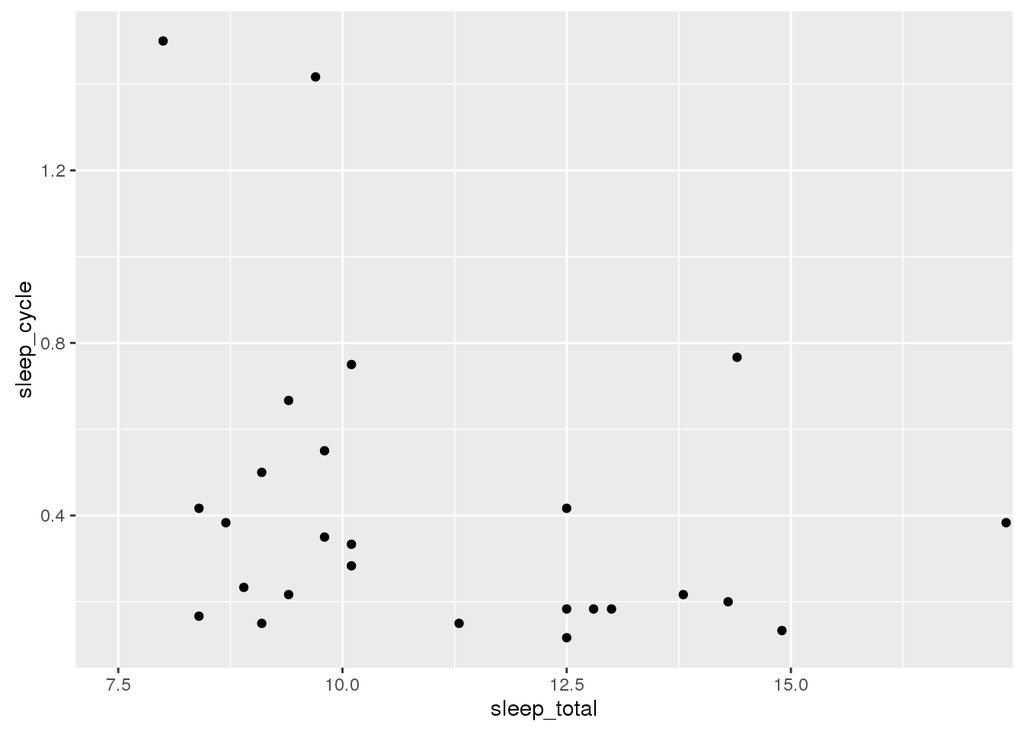

```r
ggplot(msleep, aes(x = sleep_total, y = sleep_cycle)) + geom_point() + coord_cartesian(xlim = c(7.5, 17))
```

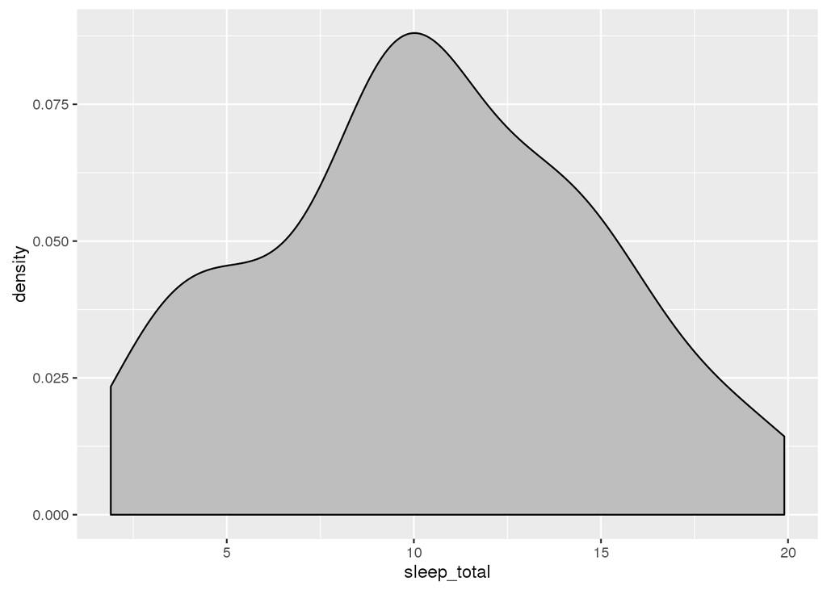

```r
ggplot(msleep, aes(x = sleep_total)) + geom_density(fill = "gray")
```

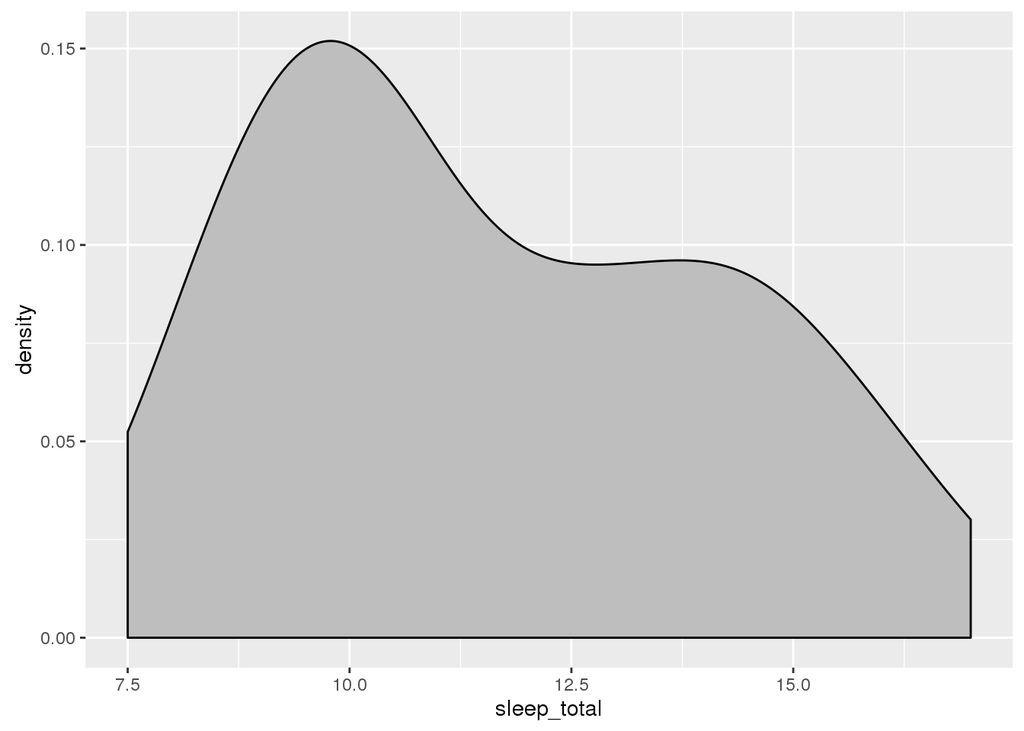

```r
ggplot(msleep, aes(x = sleep_total)) + geom_density(fill = "gray") + xlim(c(7.5, 17))
```

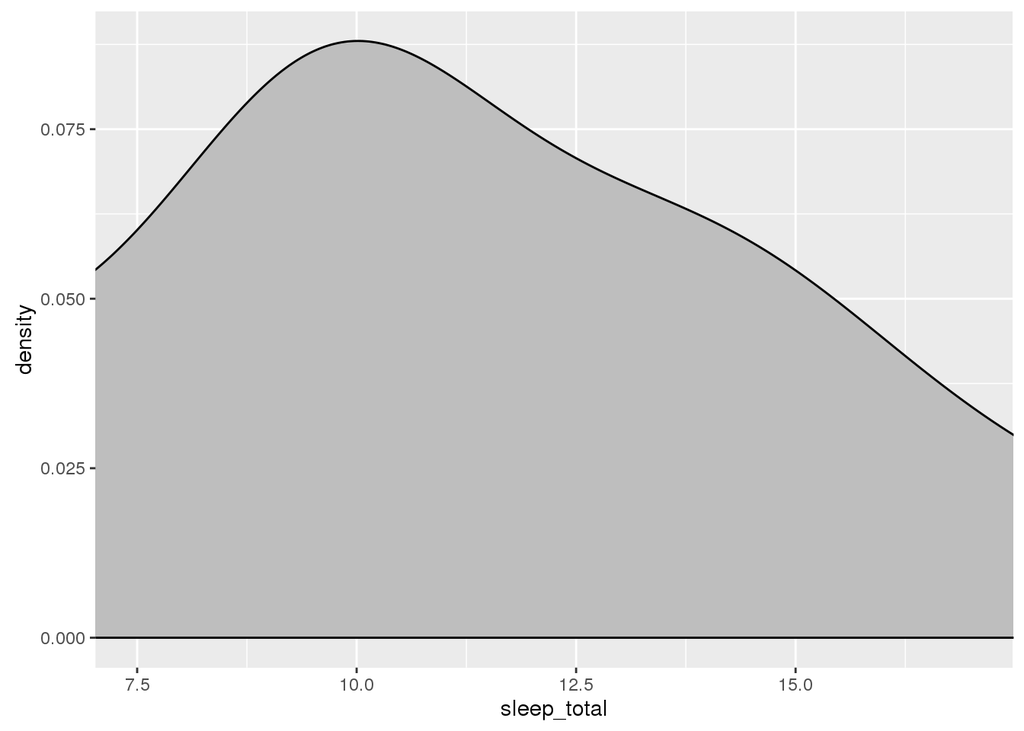

```r
ggplot(msleep, aes(x = sleep_total)) + geom_density(fill = "gray") + coord_cartesian(xlim = c(7.5, 17))
```

- axis transformation
- order
- color scales

### Themes

- default themes
- customize theme

### Faceting

Two functions for facetting: - `facet_wrap` - `facet_grid`

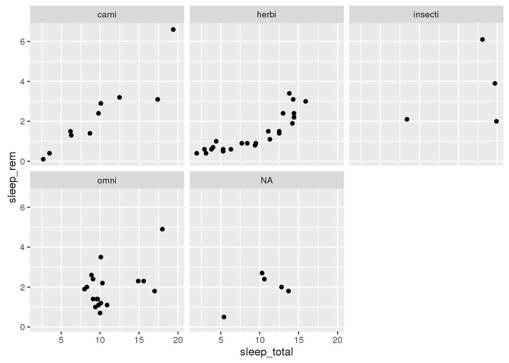

```r
ggplot(msleep, aes(x = sleep_total, y = sleep_rem)) + geom_point() + facet_wrap(~ vore)
```

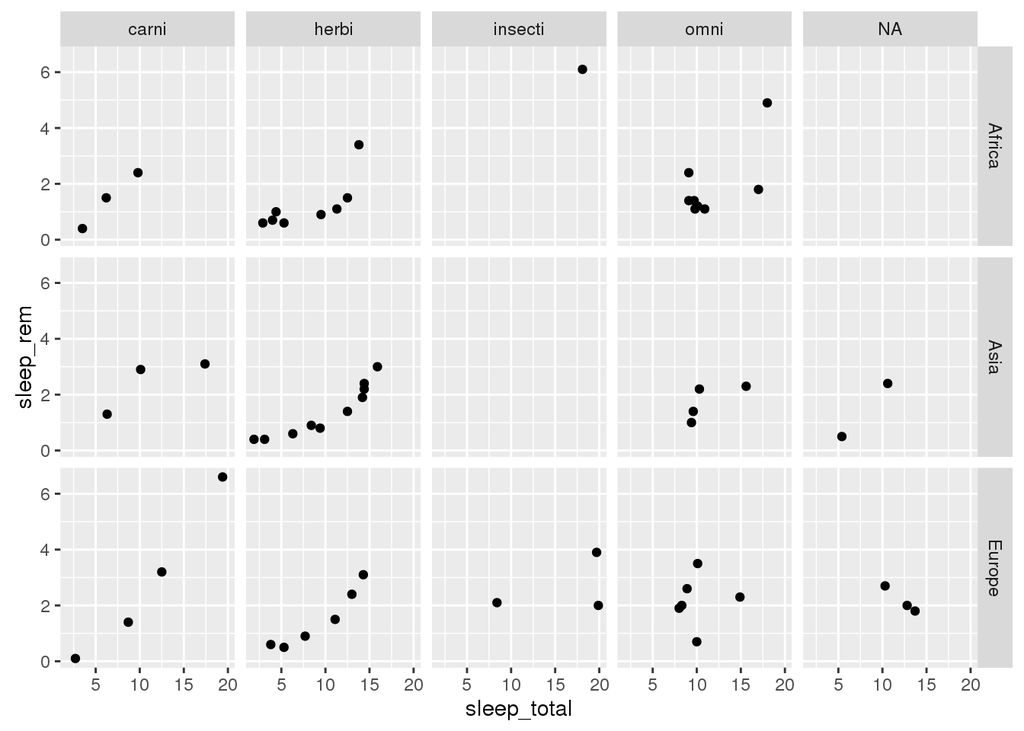

```r
ggplot(msleep, aes(x = sleep_total, y = sleep_rem)) + geom_point() + facet_grid(continent ~ vore)
```

Controling facet_wrap organisation

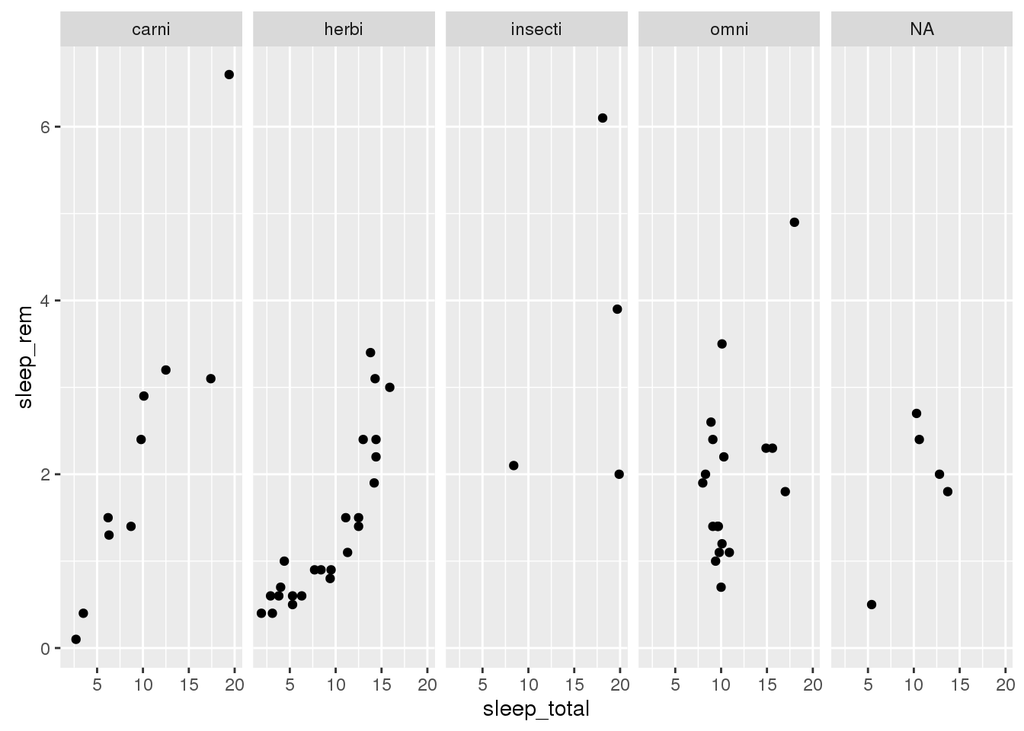

```r
ggplot(msleep, aes(x = sleep_total, y = sleep_rem)) + geom_point() + facet_wrap(~ vore, nrow = 1)
```

All layers are faceted

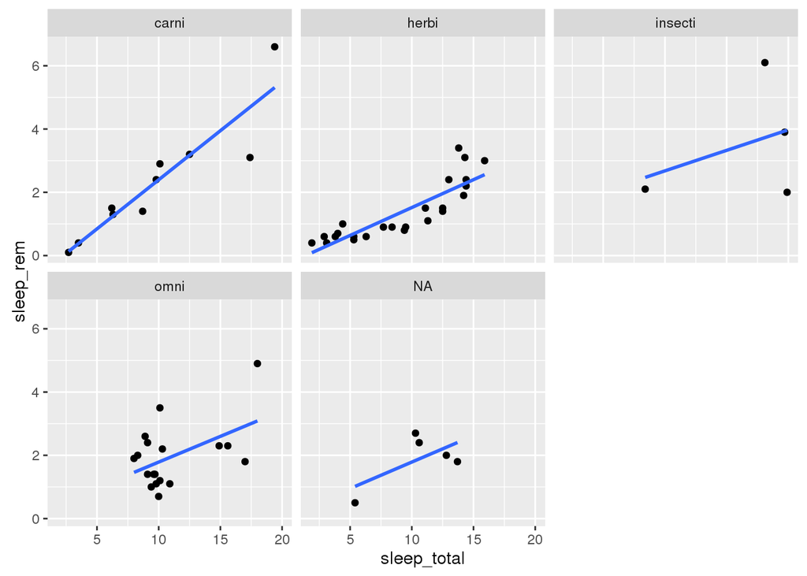

```r
ggplot(msleep, aes(x = sleep_total, y = sleep_rem)) + geom_point() + facet_wrap(~ vore) + geom_smooth(se = FALSE, method = "lm")
```

- scales free
- labels

### Programming with ggplot2

`ggplot2` use non standard evaluation (NSE). How to use variables in `aes`? `aes_string` allows standard evaluation.

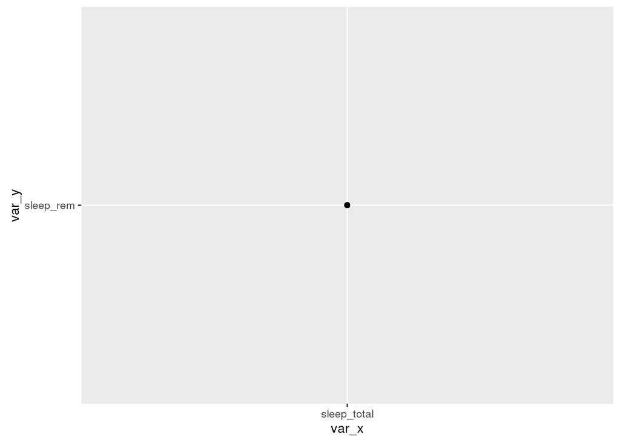

```r
var_x <- "sleep_total"
var_y <- "sleep_rem"
ggplot(msleep, aes(x = var_x, y = var_y)) + geom_point()
```

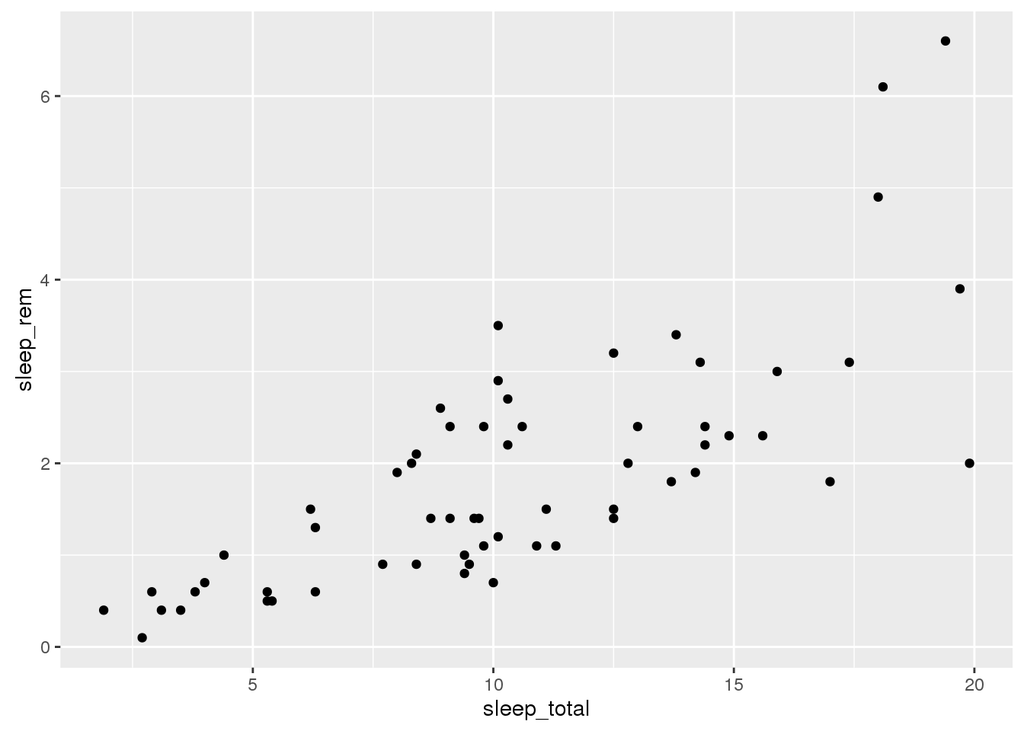

```r
ggplot(msleep, aes_string(x = var_x, y = var_y)) + geom_point()
```

### Plot heatmap with ggplot2

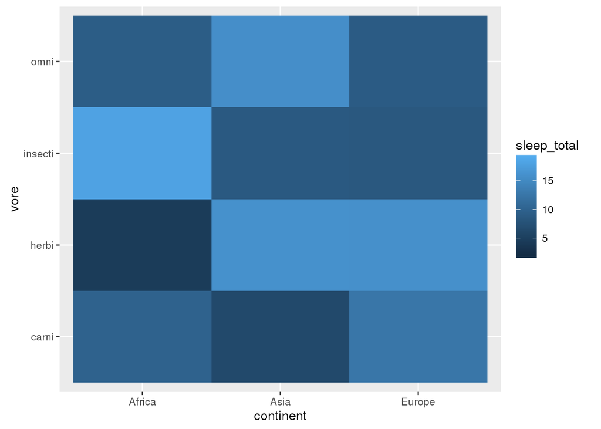

```r
ggplot(msleep, aes(x = continent, y = vore, fill = sleep_total)) + geom_tile()
```

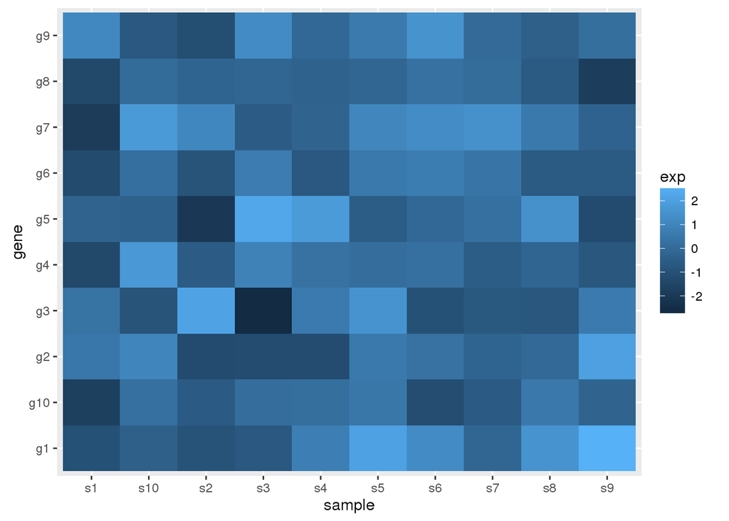

```r
d <- as.data.frame(matrix(rnorm(100), ncol = 10))
colnames(d) <- paste0("s", 1:10)
d$gene <- paste0("g", 1:10)
require(tidyr)
dm <- gather(d, key = "sample", value = "exp", -gene) ## convert data to long format
ggplot(dm, aes(x = sample, y = gene, fill = exp)) + geom_tile()
```

### Interactivity

```r
require(plotly)
g <- ggplot(msleep, aes(x = sleep_total, y = sleep_rem)) + geom_point()
ggplotly(g)
```

[interactive chart not shown]

```r
g <- ggplot(msleep, aes(x = sleep_total, y = sleep_rem, color = vore, text = name)) + geom_point()
ggplotly(g)
```

[interactive chart not shown]

### Extensions

- `ggrepel`: smart geom_text and geom_label placement
- `cowplot`: several plots on one page
- `ggraph`: visualise graph
- `ggmap`: plot data on a map
- `factoextra`: visualise results of factorial analysis (PCA, CA, MCA, MFA, …)
- `ggbio`: visualise genomic data
- `ggdendro`: visualise dendrograms and trees

### Ressources

- http://docs.ggplot2.org
- rstudio cheatsheet http://www.rstudio.com/wp-content/uploads/2015/04/ggplot2-cheatsheet.pdf